# Lab 2 Inclass: Basics of Statistics in R

SOC 325: Quantified-Self

2023-10-09

# Getting started: Editing and running code

There are several ways we can run code:

- Highlight lines in the editor window and click **Run** at the top or hit `Ctrl` + `Enter` or `CMD` + `Enter` (Mac) to run them all.
- With your caret on a line you want to run, hit `Ctrl` + `Enter` or `CMD` + `Enter` (Mac). Note your caret moves to the next line, so you can run code sequentially with repeated presses.
- Type individual lines in the console and press enter.
- In R Markdown documents, click within a code chunk and click the green arrow to run the chunk. The button beside that runs all prior chunks.

# What is data? What is statistics?

How does data fit into the scientific process?

1. Identify a question or problem (e.g. how fast did I run this month?)
2. Collect relevant data on the topic (e.g. record runs for a month)
3. Analyze the data
4. Form a conclusion

> Statistics as a subject focuses on making stages 2-4 objective, rigorous, and efficient. That is, statistics has three primary components: How best can we collect data? How should it be analyzed? And what can we infer from the analysis?
- Data: Measurement of an item/event
  - e.g., height, weight
- Statistic: Functions on the data
  - e.g., mean, meadian, mode, min, max
- Probability (distribution): Probability is the measure of the likelihood that an event will occur (Wikipedia)

*Example:*

`cars`: The data give the speed of cars and the distances taken to stop. Note that the data were recorded in the 1920s.

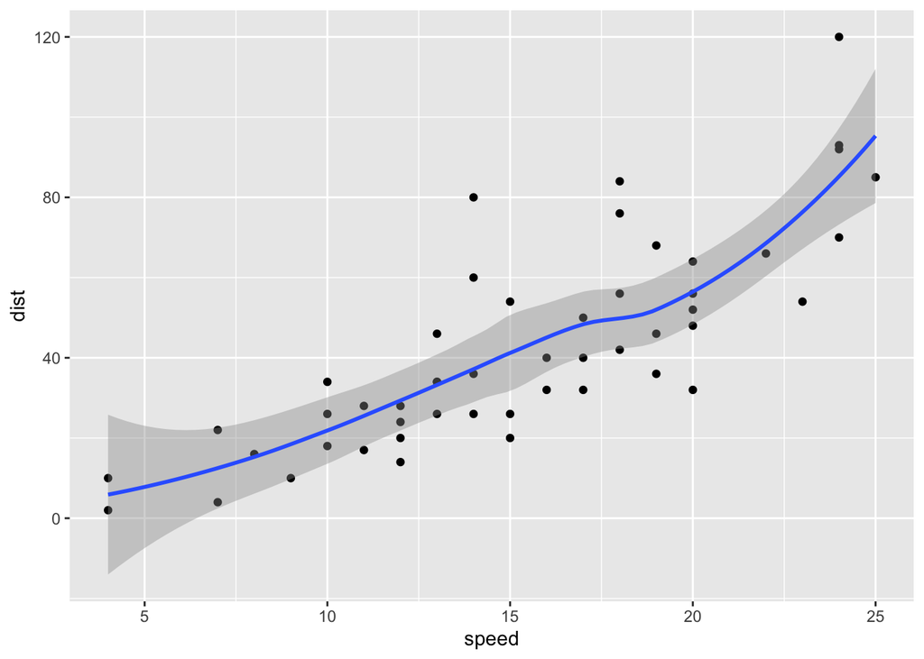

```r
cars<-datasets::cars
g <- ggplot(cars, aes(speed, dist))
g + geom_point() +
    geom_smooth()
```

## Experiments

**Treatment group** Patients in the treatment group received a stent and medical management. The medical management included medications, management of risk factors, and help in lifestyle modification.

**Control group** Patients in the control group received the same medical manage- ment as the treatment group but did not receive stents.

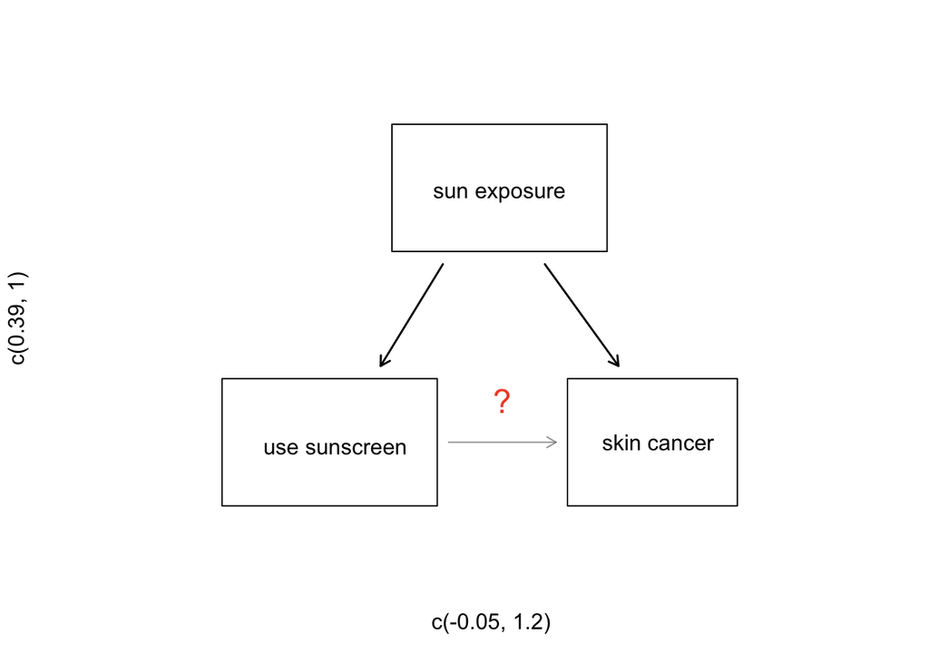

## Random Sampling

Random sampling, sometimes called probability sampling.

In a probability sample, each unit in the population has a known probability of selection This is usually done with a method for randomization (e.g., a random number generator or table).

Typically we assume there is a population (e.g., everyone who graduated from UW) and then a sample (e.g., random subset of all graduates). This could be refined sample from subgroup, e.g. random sample of graduates from health-related fields.

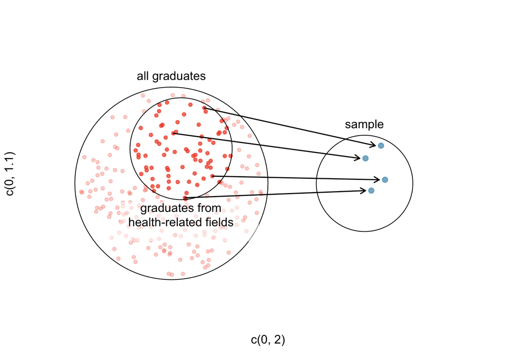

## Five Named Graphs

1. scatterplots
2. linegraphs
3. boxplots
4. histograms
5. barplots

Let’s consider *flights*

```r
library(nycflights13)
data(flights)
all_alaska_flights<-flights%>%filter(carrier=="AA")
head(all_alaska_flights)
```

```
## # A tibble: 6 × 19
##    year month   day dep_time sched_dep_time dep_delay arr_time sched_arr_time
##   <int> <int> <int>    <int>          <int>     <dbl>    <int>          <int>
## 1  2013     1     1      542            540         2      923            850
## 2  2013     1     1      558            600        -2      753            745
## 3  2013     1     1      559            600        -1      941            910
## 4  2013     1     1      606            610        -4      858            910
## 5  2013     1     1      623            610        13      920            915
## 6  2013     1     1      628            630        -2     1137           1140
## # ℹ 11 more variables: arr_delay <dbl>, carrier <chr>, flight <int>,
## #   tailnum <chr>, origin <chr>, dest <chr>, air_time <dbl>, distance <dbl>,
## #   hour <dbl>, minute <dbl>, time_hour <dttm>
```

### Scatterplots: Example

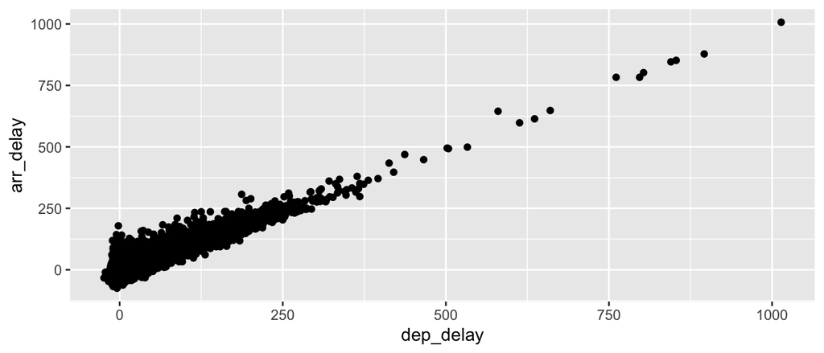

```r
ggplot(data = all_alaska_flights, aes(x = dep_delay, y = arr_delay)) +
  geom_point()
```

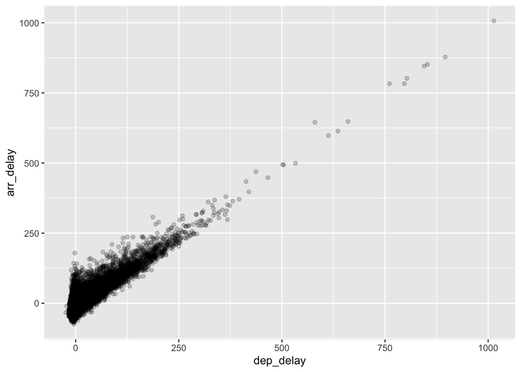

```r
ggplot(data = all_alaska_flights, mapping = aes(x = dep_delay, y = arr_delay)) +
  geom_point(alpha = 0.2)
```

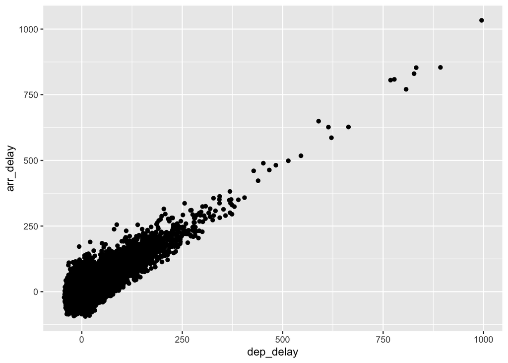

```r
ggplot(all_alaska_flights, aes(x = dep_delay, y = arr_delay)) +
  geom_jitter(width = 30, height = 30)
```

- Within the `ggplot()` function call, we specify two of the components of the grammar:
  1. The `data` frame to be `all_alaska_flights` by setting `data = all_alaska_flights`
  2. The `aes`thetic mapping by setting `aes(x = dep_delay, y = arr_delay)`. Specifically
     - the variable `dep_delay` maps to the `x` position aesthetic
     - the variable `arr_delay` maps to the `y` position aesthetic
- We add a layer to the `ggplot()` function call using the `+` sign. The layer in question specifies the third component of the grammar: the `geom`etric object. In this case the geometric object are `point`s, set by specifying `geom_point()`.

### Linegraphs

Our focus now turns to the temp variable in this weather data-set.

```r
data(weather)
head(weather)
```

```
## # A tibble: 6 × 15
##   origin  year month   day  hour  temp  dewp humid wind_dir wind_speed wind_gust
##   <chr>  <int> <int> <int> <int> <dbl> <dbl> <dbl>    <dbl>      <dbl>     <dbl>
## 1 EWR     2013     1     1     1  39.0  26.1  59.4      270      10.4         NA
## 2 EWR     2013     1     1     2  39.0  27.0  61.6      250       8.06        NA
## 3 EWR     2013     1     1     3  39.0  28.0  64.4      240      11.5         NA
## 4 EWR     2013     1     1     4  39.9  28.0  62.2      250      12.7         NA
## 5 EWR     2013     1     1     5  39.0  28.0  64.4      260      12.7         NA
## 6 EWR     2013     1     1     6  37.9  28.0  67.2      240      11.5         NA
## # ℹ 4 more variables: precip <dbl>, pressure <dbl>, visib <dbl>,
## #   time_hour <dttm>
```

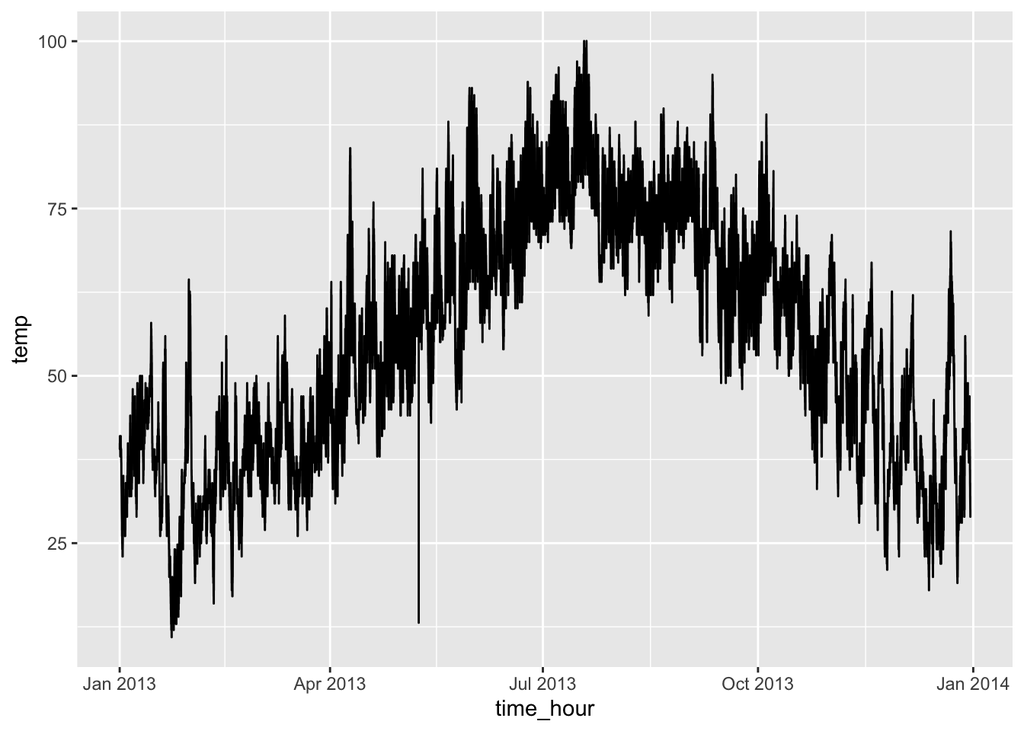

```r
ggplot(data = weather, aes(x = time_hour, y = temp)) +geom_line()
```

### Histograms

Let’s consider the `temp` variable in the `weather` data frame once again, but now unlike with the linegraphs, let’s say we don’t care about the relationship of temperature to time, but rather we care about the *(statistical) distribution* of temperatures:

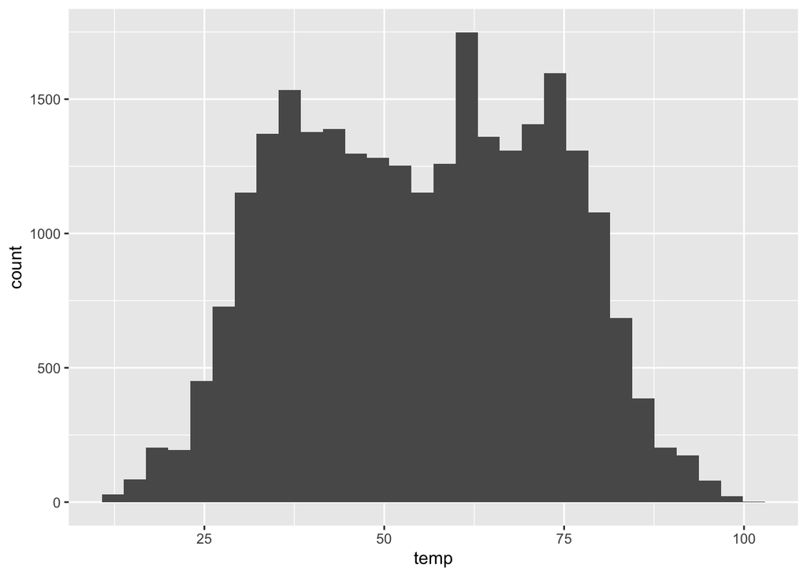

```r
ggplot(data = weather, mapping = aes(x = temp)) +
  geom_histogram()
```

# Review of Mathematics

## Scalar

Scalar. For our purposes this means, effectively, a single number in vector, e.g. $5$.

```r
5*5
```

```
## [1] 25
```

```r
5+5
```

```
## [1] 10
```

```r
5-5
```

```
## [1] 0
```

```r
5/5
```

```
## [1] 1
```

```r
class(5)
```

```
## [1] "numeric"
```

## Vector

- Vector. For our purposes this means a sequence of data of the same type.
- Created in r with `c()`.
- Checked with `is.vector()`

```r
c(5,3,4,5)
```

```
## [1] 5 3 4 5
```

```r
rep(5,5)
```

```
## [1] 5 5 5 5 5
```

```r
seq(1,5,1)
```

```
## [1] 1 2 3 4 5
```

```r
1:5
```

```
## [1] 1 2 3 4 5
```

```r
class(1:5)
```

```
## [1] "integer"
```

```r
class(c(5.5,3,4,5))
```

```
## [1] "numeric"
```

```r
is.vector(1:5)
```

```
## [1] TRUE
```

## Matrix and data.frame

- Matrix: For our purposes this means a collection of vectors.
- `data.frame` is a special R object that is a matrix which can have different types of variables on the columns.

```r
## Matrix
matrix(1:4,nc=2,nr=2,byrow = TRUE)
```

```
##      [,1] [,2]
## [1,]    1    2
## [2,]    3    4
```

```r
## data.frame
data.frame(bin=rbinom(5,1,.25),let=letters[1:5],seq=seq(1,5,1))
```

```
##   bin let seq
## 1   1   a   1
## 2   0   b   2
## 3   1   c   3
## 4   1   d   4
## 5   0   e   5
```

# Review of Statistical Inference

## Case Study: Gender Discrimination

- A study investigating gender discrimination in the 1970s
- Context, personnel decisions within a bank
- Q: Are females discriminated against in promotion decisions made by male managers?
- Experimental set up:
  - 48 male bank supervisors attending a management institute at the University of North Carolina in 1972
  - They were asked to assume the role of the personnel director of a bank and were given a personnel file to judge whether the person should be promoted to a branch manager position
  - The files given to the participants were identical
  - Except that half of them indicated the candidate was male and the other half indicated the candidate was female
  - These files were randomly assigned to the subjects
  - For each supervisor we recorded the gender associated with the assigned file and the promotion decision

```
##         decision
## gender   not promoted promoted Sum
##   female           10       14  24
##   male              3       21  24
##   Sum              13       35  48
```

**Question** Does this represent discrimination?

```
##         decision
## gender   not promoted promoted Sum
##   female           10       14  24
##   male              3       21  24
##   Sum              13       35  48
```

- 58.3% for females versus 87.5% for males

This represents 29% difference:

$$\frac{21}{24} − \frac{14}{24} =
0.292$$

> We will call this a **point estimate** of the true effect

**Formally**

- $H_0$: **Null hypothesis**. The variables gender and decision are independent. They have no relationship, and the observed difference between the proportion of males and females who were promoted, 29.2%, was due to chance.
- HA: **Alternative hypothesis**. The variables gender and decision are not indepen- dent. The difference in promotion rates of 29.2% was not due to chance, and equally qualified females are less likely to be promoted than males.

> These hypotheses are part of what is called a hypothesis test. A hypothesis test is a statistical technique used to evaluate competing claims using data. Often times, the null hypothesis takes a stance of no difference or no effect. If the null hypothesis and the data notably disagree, then we will reject the null hypothesis in favor of the alternative hypothesis.

> What would it mean if the null hypothesis, which says the variables `gender` and `decision` are unrelated, is true?

> It would mean each banker would decide whether to promote the candidate without regard to the gender indicated on the file. That is, the difference in the promotion percentages would be due to the way the files were randomly divided to the bankers, and the randomization just happened to give rise to a relatively large difference of 29.2%.

> Consider the alternative hypothesis: bankers were influenced by which gender was listed on the personnel file.

> If this was true, and especially if this influence was substan- tial, we would expect to see some difference in the promotion rates of male and female candidates. If this gender bias was against females, we would expect a smaller fraction of promotion recommendations for female personnel files relative to the male files.

**Goal:** To make *decision* and assess the quality of that *decision*, i.e., do we think discrimination is occuring in this context?

We can test this with a *statistical test*. Below is an example for Chi-Square, Fisher exact test and likelihood ratio test.

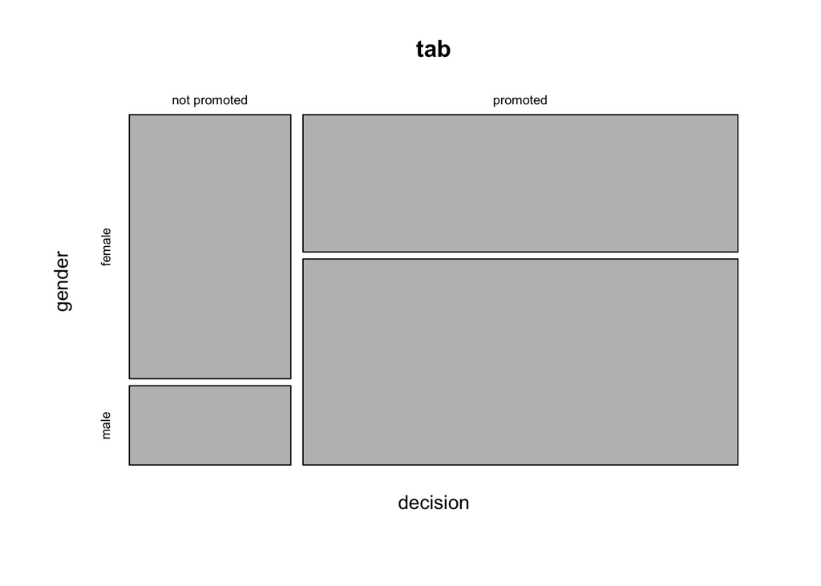

```r
tab<-table(NC_bank)
mosaicplot(tab)
```

```r
tab
```

```
##               gender
## decision       female male
##   not promoted     10    3
##   promoted         14   21
```

```r
chisq.test(tab)
```

```
##
##  Pearson's Chi-squared test with Yates' continuity correction
##
## data:  tab
## X-squared = 3.7978, df = 1, p-value = 0.05132
```

```r
fisher.test(tab)
```

```
##
##  Fisher's Exact Test for Count Data
##
## data:  tab
## p-value = 0.04899
## alternative hypothesis: true odds ratio is not equal to 1
## 95 percent confidence interval:
##   1.00557 32.20580
## sample estimates:
## odds ratio
##    4.83119
```

```r
MASS::loglm( ~ 1 + 2, data = tab)
```

```
## Call:
## MASS::loglm(formula = ~1 + 2, data = tab)
##
## Statistics:
##                       X^2 df   P(> X^2)
## Likelihood Ratio 5.386005  1 0.02029889
## Pearson          5.169231  1 0.02299039
```

## More Examples: Iris Dataset

“This famous (Fisher’s or Anderson’s) iris data set gives the measurements in centimeters of the variables sepal length and width and petal length and width, respectively, for 50 flowers from each of 3 species of iris. The species are Iris setosa, versicolor, and virginica.” `help(iris)`

```r
## Load dataset in base R
data(iris)
## Print out the first 6 rows
head(iris)
```

```
##   Sepal.Length Sepal.Width Petal.Length Petal.Width Species
## 1          5.1         3.5          1.4         0.2  setosa
## 2          4.9         3.0          1.4         0.2  setosa
## 3          4.7         3.2          1.3         0.2  setosa
## 4          4.6         3.1          1.5         0.2  setosa
## 5          5.0         3.6          1.4         0.2  setosa
## 6          5.4         3.9          1.7         0.4  setosa
```

Print out the summary statistics (min,quartiles,mean):

```r
summary(iris)
```

```
##   Sepal.Length    Sepal.Width     Petal.Length    Petal.Width
##  Min.   :4.300   Min.   :2.000   Min.   :1.000   Min.   :0.100
##  1st Qu.:5.100   1st Qu.:2.800   1st Qu.:1.600   1st Qu.:0.300
##  Median :5.800   Median :3.000   Median :4.350   Median :1.300
##  Mean   :5.843   Mean   :3.057   Mean   :3.758   Mean   :1.199
##  3rd Qu.:6.400   3rd Qu.:3.300   3rd Qu.:5.100   3rd Qu.:1.800
##  Max.   :7.900   Max.   :4.400   Max.   :6.900   Max.   :2.500
##        Species
##  setosa    :50
##  versicolor:50
##  virginica :50
##
##
##
```

Calculate the mean by group

```r
### Base R
aggregate(Sepal.Length ~ Species, iris, mean)
```

```
##      Species Sepal.Length
## 1     setosa        5.006
## 2 versicolor        5.936
## 3  virginica        6.588
```

```r
### Tidyverse
iris%>%group_by(Species)%>%summarise(mean(Sepal.Length))
```

```
## # A tibble: 3 × 2
##   Species    `mean(Sepal.Length)`
##   <fct>                     <dbl>
## 1 setosa                     5.01
## 2 versicolor                 5.94
## 3 virginica                  6.59
```

```r
cor(iris[ , 1:4])     # Return correlation matrix
```

```
##              Sepal.Length Sepal.Width Petal.Length Petal.Width
## Sepal.Length    1.0000000  -0.1175698    0.8717538   0.8179411
## Sepal.Width    -0.1175698   1.0000000   -0.4284401  -0.3661259
## Petal.Length    0.8717538  -0.4284401    1.0000000   0.9628654
## Petal.Width     0.8179411  -0.3661259    0.9628654   1.0000000
```

```r
summary(lm(Sepal.Length ~ ., iris))
```

```
##
## Call:
## lm(formula = Sepal.Length ~ ., data = iris)
##
## Residuals:
##      Min       1Q   Median       3Q      Max
## -0.79424 -0.21874  0.00899  0.20255  0.73103
##
## Coefficients:
##                   Estimate Std. Error t value Pr(>|t|)
## (Intercept)        2.17127    0.27979   7.760 1.43e-12 ***
## Sepal.Width        0.49589    0.08607   5.761 4.87e-08 ***
## Petal.Length       0.82924    0.06853  12.101  < 2e-16 ***
## Petal.Width       -0.31516    0.15120  -2.084  0.03889 *
## Speciesversicolor -0.72356    0.24017  -3.013  0.00306 **
## Speciesvirginica  -1.02350    0.33373  -3.067  0.00258 **
## ---
## Signif. codes:  0 '***' 0.001 '**' 0.01 '*' 0.05 '.' 0.1 ' ' 1
##
## Residual standard error: 0.3068 on 144 degrees of freedom
## Multiple R-squared:  0.8673, Adjusted R-squared:  0.8627
## F-statistic: 188.3 on 5 and 144 DF,  p-value: < 2.2e-16
```

```r
quantile(iris$Sepal.Length, c(0.25, 0.5, 0.75))
```

```
## 25% 50% 75%
## 5.1 5.8 6.4
```

```r
IQR(iris$Sepal.Length)
```

```
## [1] 1.3
```

```r
## Correlation test
cor.test(iris$Sepal.Length, iris$Sepal.Width, method = "pearson")
```

```
##
##  Pearson's product-moment correlation
##
## data:  iris$Sepal.Length and iris$Sepal.Width
## t = -1.4403, df = 148, p-value = 0.1519
## alternative hypothesis: true correlation is not equal to 0
## 95 percent confidence interval:
##  -0.27269325  0.04351158
## sample estimates:
##        cor
## -0.1175698
```

```r
## t-test
t.test(iris$Sepal.Length, iris$Sepal.Width)
```

```
##
##  Welch Two Sample t-test
##
## data:  iris$Sepal.Length and iris$Sepal.Width
## t = 36.463, df = 225.68, p-value < 2.2e-16
## alternative hypothesis: true difference in means is not equal to 0
## 95 percent confidence interval:
##  2.63544 2.93656
## sample estimates:
## mean of x mean of y
##  5.843333  3.057333
```

```r
## chisq-test
chisq.test(iris$Sepal.Length, iris$Sepal.Width)
```

```
##
##  Pearson's Chi-squared test
##
## data:  iris$Sepal.Length and iris$Sepal.Width
## X-squared = 784.28, df = 748, p-value = 0.1735
```

```r
summary(lm(Sepal.Length ~ Species, data = iris))
```

```
##
## Call:
## lm(formula = Sepal.Length ~ Species, data = iris)
##
## Residuals:
##     Min      1Q  Median      3Q     Max
## -1.6880 -0.3285 -0.0060  0.3120  1.3120
##
## Coefficients:
##                   Estimate Std. Error t value Pr(>|t|)
## (Intercept)         5.0060     0.0728  68.762  < 2e-16 ***
## Speciesversicolor   0.9300     0.1030   9.033 8.77e-16 ***
## Speciesvirginica    1.5820     0.1030  15.366  < 2e-16 ***
## ---
## Signif. codes:  0 '***' 0.001 '**' 0.01 '*' 0.05 '.' 0.1 ' ' 1
##
## Residual standard error: 0.5148 on 147 degrees of freedom
## Multiple R-squared:  0.6187, Adjusted R-squared:  0.6135
## F-statistic: 119.3 on 2 and 147 DF,  p-value: < 2.2e-16
```

```r
model <- lm(Sepal.Length ~ Species, data = iris)
anova(model)
```

```
## Analysis of Variance Table
##
## Response: Sepal.Length
##            Df Sum Sq Mean Sq F value    Pr(>F)
## Species     2 63.212  31.606  119.26 < 2.2e-16 ***
## Residuals 147 38.956   0.265
## ---
## Signif. codes:  0 '***' 0.001 '**' 0.01 '*' 0.05 '.' 0.1 ' ' 1
```